# 287g_coverage

Claire Morton

2026-04-21

Assess total people covered by agreements by state over time

Plotting number of people covered by 287g agreements by type and state.

Note that the coverage double counts (or triple, or quadruple) people who are covered by more than one agreement. This is why Florida has so many more people covered than its state population, for example.

I did it this way because this was the most straightforward way to get exposure to 287g, since the dataset I have has each agreement and the number of people covered by it.

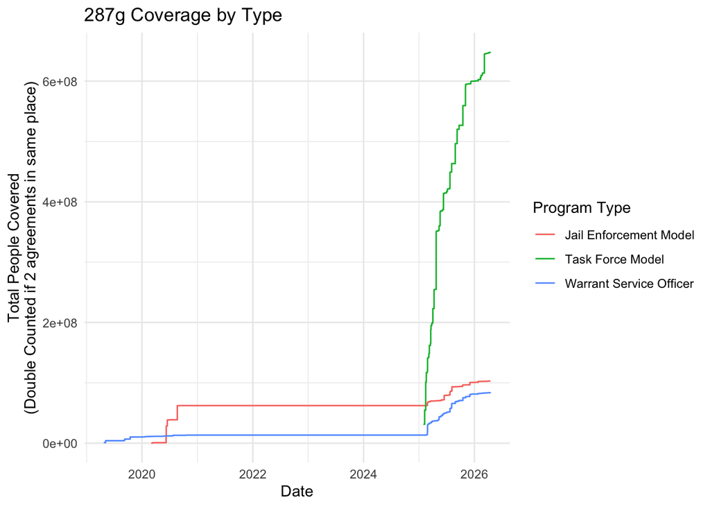

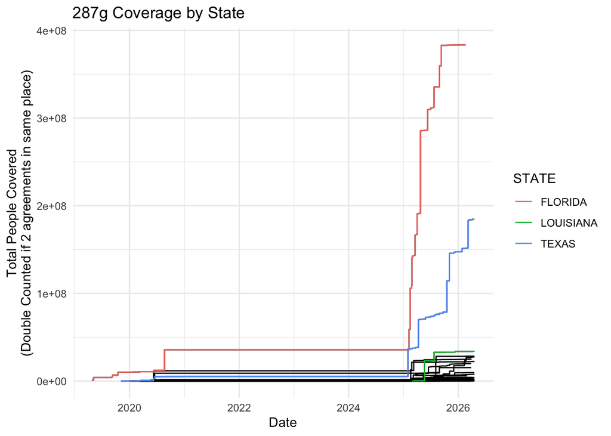

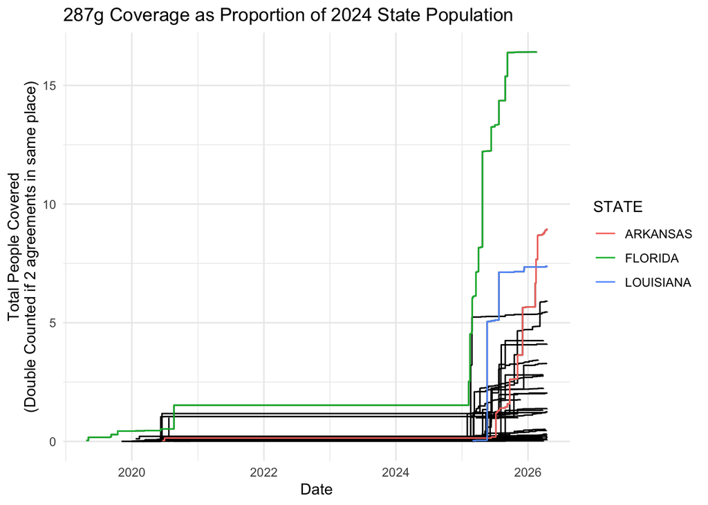

Sanity check: Does it look like we’re having more 287g arrests in states with more 287g agreement coverage at the time of arrest?

Arrest state lines up reasonably well with AOR and will better allow us to join with the 287g data.

```
##
##                                         ALABAMA ALASKA ARIZONA ARKANSAS
##   Atlanta Area of Responsibility             16      0       3        0
##   Baltimore Area of Responsibility            0      0       0        0
##   Boston Area of Responsibility               7      0       0        0
##   Buffalo Area of Responsibility              0      0       0        0
##   Chicago Area of Responsibility              1      0       5        0
##   Dallas Area of Responsibility               0      0       4        1
##   Denver Area of Responsibility               0      0       1        0
##   Detroit Area of Responsibility              0      0       1        0
##   El Paso Area of Responsibility              0      0       1        0
##   Harlingen Area of Responsibility            1      0       2        0
##   Houston Area of Responsibility              0      0       0        0
##   HQ Area of Responsibility                   0      0       0        0
##   Los Angeles Area of Responsibility          0      0       9        0
##   Miami Area of Responsibility                4      0       0        0
##   New Orleans Area of Responsibility      10257      4       1     6882
##   New York City Area of Responsibility        1      0       0        0
##   Newark Area of Responsibility               0      0       0        0
##   Philadelphia Area of Responsibility         0      0       0        0
##   Phoenix Area of Responsibility              6      2   15942        1
##   Salt Lake City Area of Responsibility       0      0       5        0
##   San Antonio Area of Responsibility          1      0       1        0
##   San Diego Area of Responsibility            1      0      14        0
##   San Francisco Area of Responsibility        0      0       1        1
##   Seattle Area of Responsibility              0    203       1        0
##   St. Paul Area of Responsibility             1      0       0        0
##   Washington Area of Responsibility           0      0       0        0
##
##                                         ARMED FORCES - EUROPE
##   Atlanta Area of Responsibility                            0
##   Baltimore Area of Responsibility                          1
##   Boston Area of Responsibility                             0
##   Buffalo Area of Responsibility                            0
##   Chicago Area of Responsibility                            0
##   Dallas Area of Responsibility                             0
##   Denver Area of Responsibility                             0
##   Detroit Area of Responsibility                            0
##   El Paso Area of Responsibility                            0
##   Harlingen Area of Responsibility                          0
```

[output cut: 533 more lines]

```
##   HQ Area of Responsibility                   0
##   Los Angeles Area of Responsibility          0
##   Miami Area of Responsibility                0
##   New Orleans Area of Responsibility          0
##   New York City Area of Responsibility        1
##   Newark Area of Responsibility               0
##   Philadelphia Area of Responsibility         0
##   Phoenix Area of Responsibility              0
##   Salt Lake City Area of Responsibility       0
##   San Antonio Area of Responsibility          0
##   San Diego Area of Responsibility            0
##   San Francisco Area of Responsibility        0
##   Seattle Area of Responsibility              1
##   St. Paul Area of Responsibility             0
##   Washington Area of Responsibility           0
```

Looking at Arkansas, Florida, and Louisiana, which had the highest proportion of 287g per population in March 2026. They also had slightly different times of ramping up their 287g programs in terms of people covered – Florida, then Louisiana, then Arkansas.

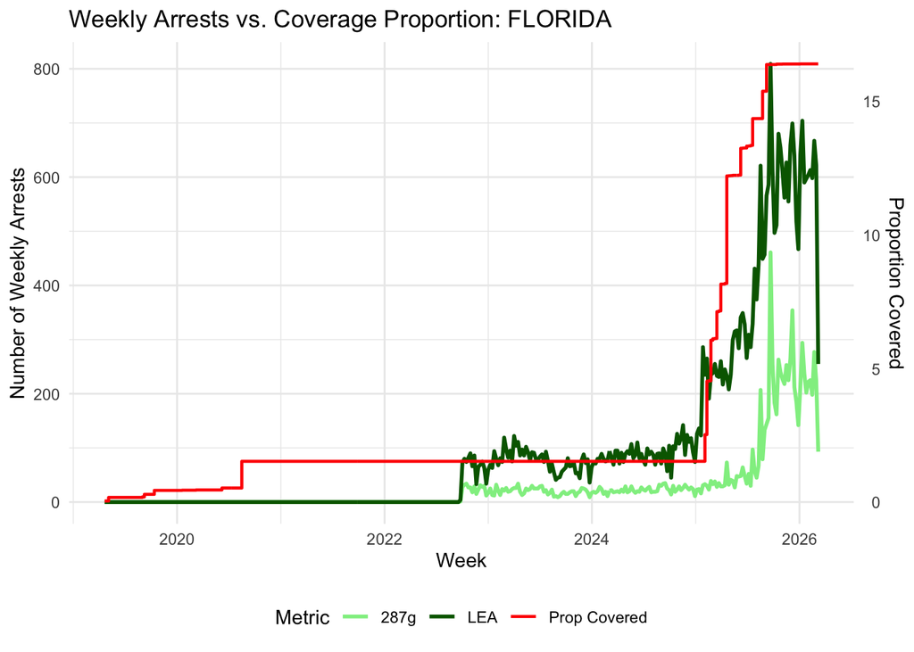

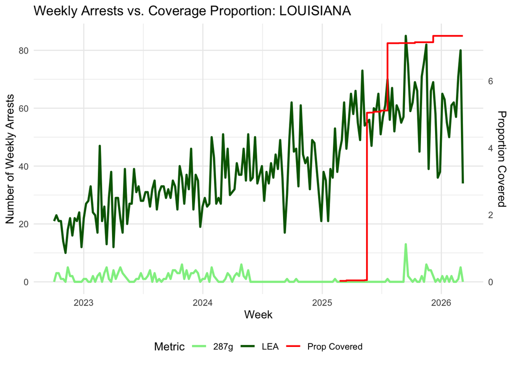

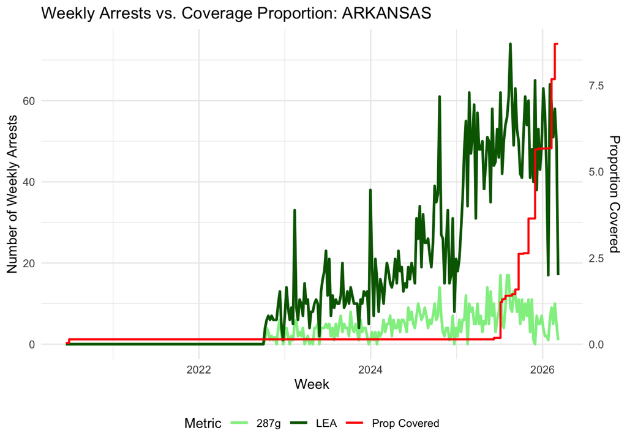

Plotting proprotion of arrestees with criminal convictions

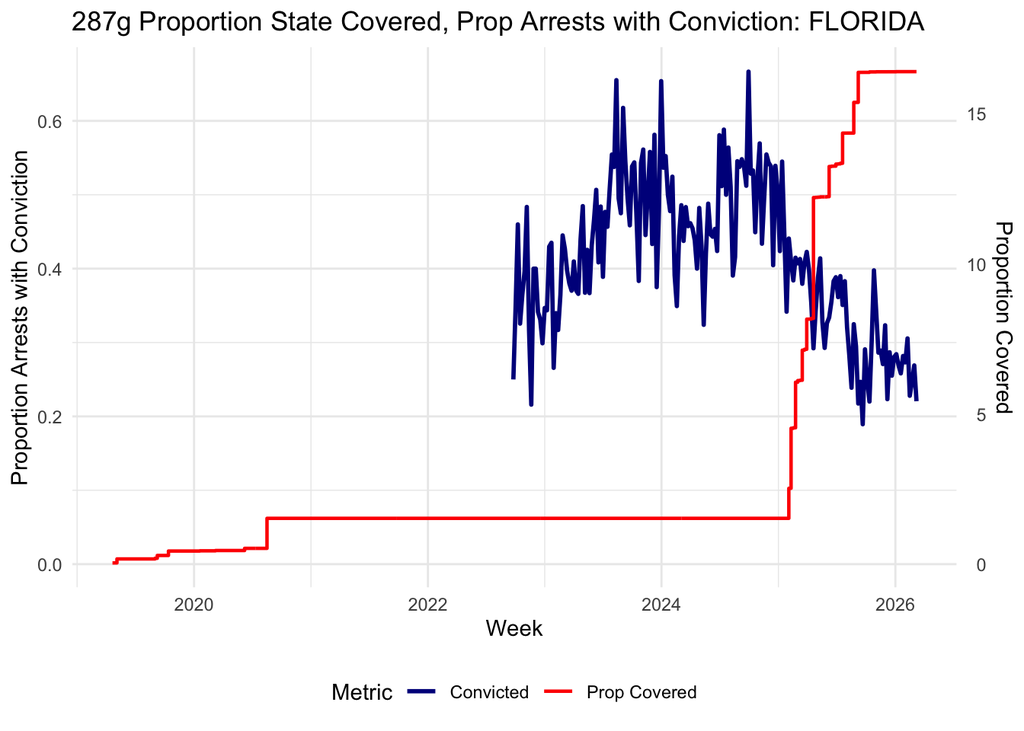

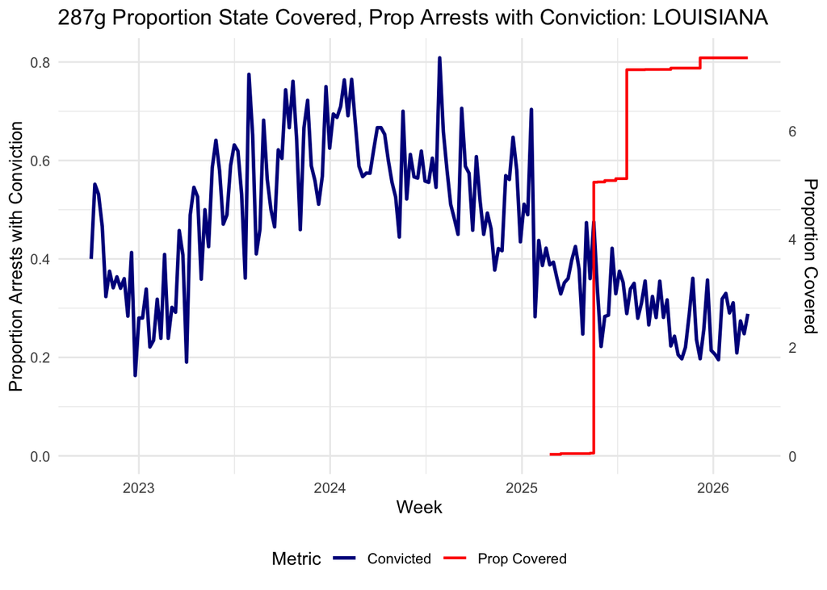

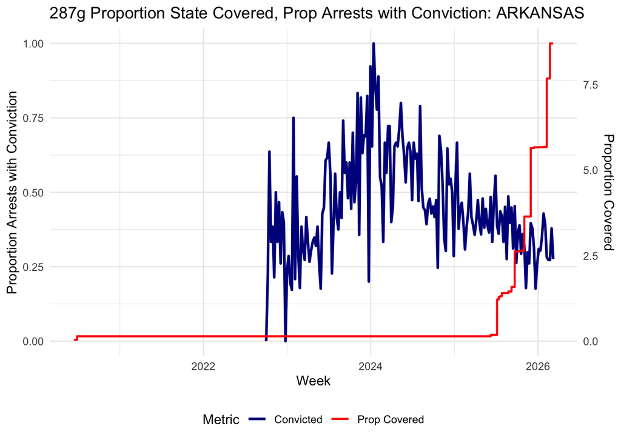